# Texas Police Stops Analysis

Visualising Open Data

Alexander Turner

## Required Packages

```r
library(tidyverse)
library(magrittr)
```

## Data Information

The data for this project was obtained from the [Stanford Open Policing Project](https://openpolicing.stanford.edu/) and is released under the Open Data Commons Attribution License. A team of interdisciplinary researchers at Stanford are attempting to create a comprehensive repository of all police traffic stops in the USA, in order to promote the investigation and improvement of policing practices. This analysis will focus on the traffic stops in the state of Texas from 2010 to 2015 and examine the police search and hit rates (a hit occurs when contraband is found during a search) for black, Hispanic and white drivers. These 3 racial groups account for ~97% of the traffic stops in Texas. A detailed summary of the data can be found [here](https://github.com/5harad/openpolicing/blob/master/DATA-README.md).

## Data

```r
# import data
texas_stops <- read_csv("C:/RStudio Projects/Data Visualisation/Assignment 2/TX_2010_onwards.csv")

# data
head(texas_stops)
```

```
## # A tibble: 6 x 26
##   id      state stop_date  stop_time location_raw county_name  county_fips
##   <chr>   <chr> <date>     <time>    <chr>        <chr>              <int>
## 1 TX-201~ TX    2010-01-01 00'00"    Guadalupe    Guadalupe C~       48187
## 2 TX-201~ TX    2010-01-01 00'00"    Fannin       Fannin Coun~       48147
## 3 TX-201~ TX    2010-01-01 00'00"    Coryell      Coryell Cou~       48099
## 4 TX-201~ TX    2010-01-01 00'00"    Dallas       Dallas Coun~       48113
## 5 TX-201~ TX    2010-01-01 00'00"    Denton       Denton Coun~       48121
## 6 TX-201~ TX    2010-01-01 00'00"    Denton       Denton Coun~       48121
## # ... with 19 more variables: fine_grained_location <int>,
## #   police_department <chr>, driver_gender <chr>, driver_age_raw <chr>,
## #   driver_age <chr>, driver_race_raw <chr>, driver_race <chr>,
## #   violation_raw <chr>, violation <chr>, search_conducted <lgl>,
## #   search_type_raw <chr>, search_type <chr>, contraband_found <lgl>,
## #   stop_outcome <chr>, is_arrested <chr>, lat <dbl>, lon <dbl>,
## #   officer_id <chr>, driver_race_original <chr>
```

```r
# define driver race variable as factor
texas_stops$driver_race <- texas_stops$driver_race %>% factor()

# create data frames for plot
# 1st plot
plot_data <- texas_stops %>%
  filter(
    !is.na(county_name)
    & !is.na(driver_race)
    & !is.na(search_conducted)
    & driver_race != "Other"
    & driver_race != "Asian"
    ) %>%
  group_by(county_name, driver_race) %>%
  summarise(
    total_stops = n(),
    search_rate = sum(search_conducted, na.rm = T)/n()*100,
    hit_rate = sum(contraband_found, na.rm = T)/sum(search_conducted, na.rm = T)*100
    )

# 2nd plot
summary_stats <- texas_stops %>%
  filter(
    !is.na(driver_race)
    & !is.na(search_conducted)
    & driver_race != "Other"
    & driver_race != "Asian"
    ) %>%
  group_by(driver_race) %>%
  summarise(
    search_rate = sum(search_conducted, na.rm = T)/n()*100,
    hit_rate = sum(contraband_found, na.rm = T)/sum(search_conducted, na.rm = T)*100,
    total_stops = n()
    )

# convert to long format for plotting
summary_stats <- summary_stats %>%
  gather(variable, value, -1)

# define variable as factor so order is correct in plot & labels are clean
summary_stats$variable <- summary_stats$variable %>%
  factor(levels = c("total_stops", "search_rate", "hit_rate"),
         labels = c("Total Stops", "Search Rate %", "Hit Rate %"))
```

## Visualisation

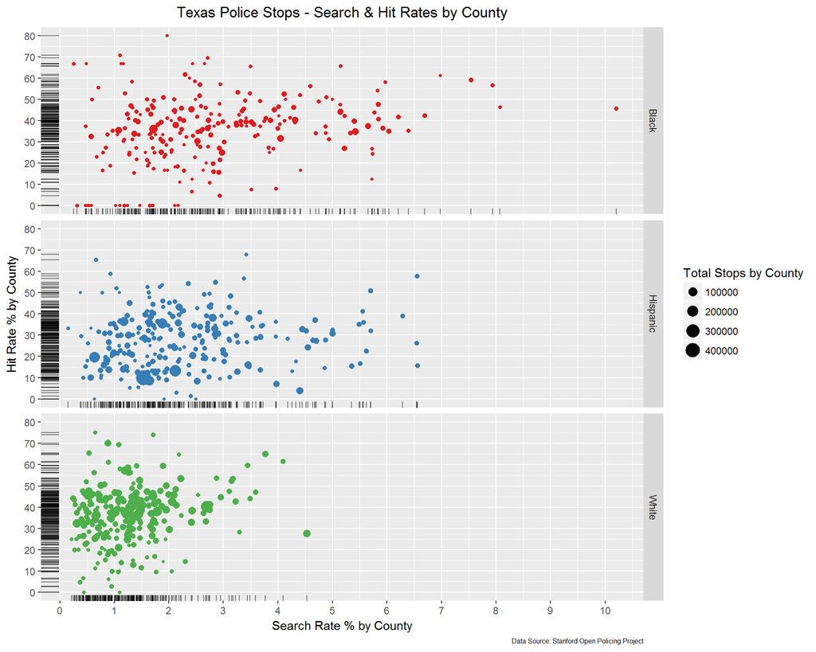

```r
#remove scientific notation for legend
options(scipen = 999)

# create 1st plot & apply filter to remove outliers caused by small samples & NaN values
p1 <- ggplot(filter(plot_data, !is.nan(hit_rate) & total_stops >= 100),
             aes(search_rate, hit_rate, size = total_stops, colour = driver_race)) +
  geom_point() +
  geom_rug(colour = "black", size = 0.5, alpha = 0.5) +
  facet_grid(driver_race~.) +
  scale_colour_brewer(palette = "Set1") +
  scale_x_continuous(breaks = seq(0, 10, by = 1)) +
  scale_y_continuous(breaks = seq(0, 80, by = 10)) +
  labs(title = "Texas Police Stops - Search & Hit Rates by County",
       x = "Search Rate % by County",
       y = "Hit Rate % by County",
       size = "Total Stops by County",
       caption = "Data Source: Stanford Open Policing Project") +
  theme(plot.title = element_text(hjust = 0.5),
        plot.caption = element_text(size = 6)) +
  guides(colour = F)

# 1st plot
p1
```

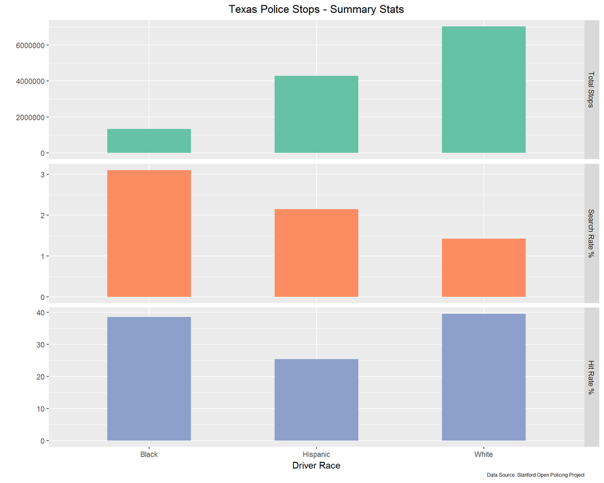

```r
#create 2nd plot
p2 <- ggplot(summary_stats, aes(driver_race, value, fill = variable)) +
  geom_col(width = 0.5) +
  facet_grid(variable~., scales = "free") +
  scale_fill_brewer(palette = "Set2") +
  labs(title = "Texas Police Stops - Summary Stats",
       x = "Driver Race",
       y = "",
       caption = "Data Source: Stanford Open Policing Project") +
  theme(plot.title = element_text(hjust = 0.5),
        plot.caption = element_text(size = 6),
        legend.position = "none")

# 2nd plot
p2
```

## Summary

It is clear from the plots that a number of inferences can be drawn in regards to policing practices in Texas. Firstly, the summary plots indicate that minority groups are searched at higher rates, despite having lower hit rates. This means both the benchmark and outcome tests for discrimination are failed, meaning it is suggested that discrimination is in fact present. It cannot be said for certain that discrimination is taking place though, due to the [subtle statistical issue of infra-marginality](https://5harad.com/papers/threshold-test.pdf). The total stops by race differences can mostly be attributed to [Texas’ underlying demographics](https://www.census.gov/quickfacts/TX).

When looking at the plots which break down search and hit rates by county other trends become apparent. The x-axis points on the white driver plot are bunched relatively tightly on the left hand side, showing that across counties search rates for this group are low. In contrast, there is considerable spread across the x-axis for black and Hispanic drivers, which shows the higher minority search rates are driven by state-wide trends rather than a few outliers with a high number of stops. For the hit rate, it can be seen that the lower overall figure for Hispanic drivers is caused in part by a few high-stop counties with low hit rates.